# Python version of Omni Analytics' Data Science on the Ethereum Blockchain Module 1-2: Reading Files.

## All datasets, code ideas, concepts, and text used are based on Omni Analytics' great work that can be found here: https://github.com/Omni-Analytics-Group/eth-data-science-course

### Translation from R into Python by Jeanna Schoonmaker, Oct 2021

# Outline

- Reading files: Excel and .csv

# Importing Data

We often need to import our own data rather than just using built-in datasets. The following steps are usually taken:

- Import the pandas library for reading data files
- Use pandas functions such as:
  - pd.read_csv(filename)
  - pd.read_excel(filename)
- Assign the data to a variable name when reading in the file.

# Importing Data Demo

We load a file in by identifying where in our system the file is stored and then enclosing that filepath in the pd.read_csv parentheses. For this example, we will load the dataset from the github directory where it is stored for this course.

Common practice is to load dataframes (tabular data from a csv) with the name "df."

```python
import pandas as pd
crypto_art_filename = 'https://raw.githubusercontent.com/Omni-Analytics-Group/eth-data-science-course/master/courses/Module%201/crypto_art_pulse.csv'
crypto_art_df = pd.read_csv(crypto_art_filename)
```

# Data in Excel

Excel has file formats such as xls and csv - so what are the differences? File extensions .xls or .xlsx are proprietary Excel formats, and they are binary files. .csv is the extension for comma separated value files. They are text files and are directly readable.

# Excel file in Excel

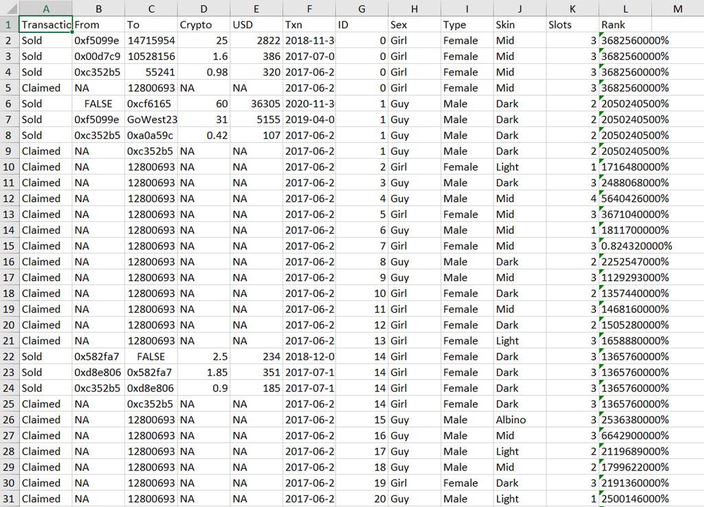

# .csv file in notepad

[figure not shown]

# Reading Files in Python

Comma separated or tabular separated files can both be loaded with pd.read_csv

This code is used for a comma separated file:

```
pd.read_csv(filename)
```

This code is used for a tab separated file:

```
pd.read_csv(filename, sep="\t")
```

# Reading .csv Files

The pd.read_csv also needs special instructions on how to handle some of the unicode characters in the data file, which is why "encoding = 'unicode_escape'" is included.

```python
punks_file = 'https://raw.githubusercontent.com/Omni-Analytics-Group/eth-data-science-course/master/courses/Module%201/punks.csv'
df_punks = pd.read_csv(punks_file, encoding='unicode_escape')
df_punks.head()
```

|  | Transaction | From | To | Crypto | USD | Txn | ID | Sex | Type | Skin | Slots | Rank |
| --- | --- | --- | --- | --- | --- | --- | --- | --- | --- | --- | --- | --- |
| 0 | Sold | 0xf5099e | 14715954 | 25.00 | 2822.0 | 2018-11-30 | 0 | Girl | Female | Mid | 3 | 3682560000% |
| 1 | Sold | 0x00d7c9 | 10528156 | 1.60 | 386.0 | 2017-07-07 | 0 | Girl | Female | Mid | 3 | 3682560000% |
| 2 | Sold | 0xc352b5 | 55241 | 0.98 | 320.0 | 2017-06-23 | 0 | Girl | Female | Mid | 3 | 3682560000% |
| 3 | Claimed | NaN | 12800693 | NaN | NaN | 2017-06-23 | 0 | Girl | Female | Mid | 3 | 3682560000% |
| 4 | Sold | EliteCat | 0xcf6165 | 60.00 | 36305.0 | 2020-11-30 | 1 | Guy | Male | Dark | 2 | 2050240500% |

```python
df_punks.info()
```

```
<class 'pandas.core.frame.DataFrame'>
RangeIndex: 17554 entries, 0 to 17553
Data columns (total 12 columns):
 #   Column       Non-Null Count  Dtype
---  ------       --------------  -----
 0   Transaction  17554 non-null  object
 1   From         7554 non-null   object
 2   To           17554 non-null  object
 3   Crypto       7554 non-null   float64
 4   USD          7554 non-null   float64
 5   Txn          17554 non-null  object
 6   ID           17554 non-null  int64
 7   Sex          17554 non-null  object
 8   Type         17554 non-null  object
 9   Skin         17554 non-null  object
 10  Slots        17554 non-null  int64
 11  Rank         17554 non-null  object
dtypes: float64(2), int64(2), object(8)
memory usage: 1.6+ MB
```

# Reading Excel Files

The pandas library can also handle reading excel files.

1. In order to access an Excel file in Google colab, first go to this link and click "Download." Make note of where your downloaded file is stored: https://github.com/Omni-Analytics-Group/eth-data-science-course/blob/master/courses/Module%201/punks.xlsx
2. Click on the file folder icon in the left hand sidebar on your Google Colab screen.
3. Click on the "Upload" icon, then navigate to the folder where the punks.xlsx file you just downloaded is stored and click on the punks.xlsx file.
4. When the punks.xlsx file shows up in the Files list, hover your mouse over it and click on the 3 vertical dots to the right of the filename, then click on "Copy path."
5. Paste the copied path after the equal sign in the first line of the code below:

```python
punks_excel_file = '/content/punks.xlsx' # post your copied path between the single quotation marks
df_punks_excel = pd.read_excel(punks_excel_file, 'Worksheet')
df_punks_excel.head()
```

|  | Transaction | From | To | Crypto | USD | Txn | ID | Sex | Type | Skin | Slots | Rank |
| --- | --- | --- | --- | --- | --- | --- | --- | --- | --- | --- | --- | --- |
| 0 | Sold | 0xf5099e | 14715954 | 25.00 | 2822.0 | 2018-11-30 | 0 | Girl | Female | Mid | 3 | 3682560000% |
| 1 | Sold | 0x00d7c9 | 10528156 | 1.60 | 386.0 | 2017-07-07 | 0 | Girl | Female | Mid | 3 | 3682560000% |
| 2 | Sold | 0xc352b5 | 55241 | 0.98 | 320.0 | 2017-06-23 | 0 | Girl | Female | Mid | 3 | 3682560000% |
| 3 | Claimed | NaN | 12800693 | NaN | NaN | 2017-06-23 | 0 | Girl | Female | Mid | 3 | 3682560000% |
| 4 | Sold | False | 0xcf6165 | 60.00 | 36305.0 | 2020-11-30 | 1 | Guy | Male | Dark | 2 | 2050240500% |

# Your Turn

Using the crypto_art_pulse.csv file, do the following:

1. Read the data into a dataframe called crypto_art_df
2. Use the head() function to display some rows
3. Use the info() function to see each variable type

# Answers

# 1. Read the data into a dataframe called crypto_art_df

```python
crypto_art_filename = 'https://raw.githubusercontent.com/Omni-Analytics-Group/eth-data-science-course/master/courses/Module%201/crypto_art_pulse.csv'
crypto_art_df = pd.read_csv(crypto_art_filename)
```

# 2. Use the head() function to display some rows

```python
crypto_art_df.head()
```

|  | asset_token_id | asset_contract_address | asset_collection | asset_name | asset_artist | asset_image | asset_link | asset_external_link | asset_first_sale_price | asset_last_sale_price | asset_last_sale_owner_name | asset_last_sale_owner_address | asset_sale_grows | asset_num_sales | asset_last_sale_date |
| --- | --- | --- | --- | --- | --- | --- | --- | --- | --- | --- | --- | --- | --- | --- | --- |
| 0 | 211201 | 0xfbeef911dc5821886e1dda71586d90ed28174b7d | Known-origin | Wi-Five / Cuban Impressions | Adoption | https://lh3.googleusercontent.com/RAcLH_YifV2a... | https://opensea.io/assets/0xfbeef911dc5821886e... | https://knownorigin.io/token/211201 | 800000000000000000 | 800000000000000000 | mattiac | 0x576a655161b5502dcf40602be1f3519a89b71658 | 0.0 | 1 | 2020-12-31 14:02:57 |
| 1 | 16773 | 0xb932a70a57673d89f4acffbe830e8ed7f75fb9e0 | Superrare | SUBTERRANEAN HOMESICK ALIEN (TRIBUTE) | rubahitam | https://lh3.googleusercontent.com/pKhMQQNVUt3J... | https://opensea.io/assets/0xb932a70a57673d89f4... | https://superrare.co/?origin=https%3A%2F%2Fope... | 1500000000000000000 | 1500000000000000000 | NaN | 0x9dac76101b5ccda5970e60402de31a6649115b53 | 0.0 | 1 | 2020-12-31 13:35:20 |
| 2 | 16113 | 0xb932a70a57673d89f4acffbe830e8ed7f75fb9e0 | Superrare | Somewhere | MrY | https://lh3.googleusercontent.com/9ycKTkeIZTro... | https://opensea.io/assets/0xb932a70a57673d89f4... | https://superrare.co/?origin=https%3A%2F%2Fope... | 500000000000000000 | 500000000000000000 | endless_traveler | 0x423a0a0f3479ab24b2b04c8dba8bbe0e2bbb5cc6 | 0.0 | 1 | 2020-12-31 13:19:51 |
| 3 | 17443 | 0xb932a70a57673d89f4acffbe830e8ed7f75fb9e0 | Superrare | TINY ROOMS TWO - IN DA CLUB 2020 EDITION | MrY | https://lh3.googleusercontent.com/WgD9n7W0B8Et... | https://opensea.io/assets/0xb932a70a57673d89f4... | https://superrare.co/?origin=https%3A%2F%2Fope... | 500000000000000000 | 500000000000000000 | endless_traveler | 0x423a0a0f3479ab24b2b04c8dba8bbe0e2bbb5cc6 | 0.0 | 1 | 2020-12-31 13:19:51 |
| 4 | 38926 | 0x2a46f2ffd99e19a89476e2f62270e0a35bbf0756 | Makersplace | Boredoom | wizmo | https://lh3.googleusercontent.com/HY5jSHOtLn3g... | https://opensea.io/assets/0x2a46f2ffd99e19a894... | https://makersplace.com/product/token/0x2a46f2... | 500000000000000000 | 500000000000000000 | brandonkangfilms | 0x720a4fab08cb746fc90e88d1924a98104c0822cf | 0.0 | 1 | 2020-12-31 09:28:46 |

# 3. Use the info() function to see each variable type

```python
crypto_art_df.info()
```

```
<class 'pandas.core.frame.DataFrame'>
RangeIndex: 25336 entries, 0 to 25335
Data columns (total 15 columns):
 #   Column                         Non-Null Count  Dtype
---  ------                         --------------  -----
 0   asset_token_id                 25336 non-null  int64
 1   asset_contract_address         25336 non-null  object
 2   asset_collection               25336 non-null  object
 3   asset_name                     25335 non-null  object
 4   asset_artist                   25299 non-null  object
 5   asset_image                    25336 non-null  object
 6   asset_link                     25336 non-null  object
 7   asset_external_link            25215 non-null  object
 8   asset_first_sale_price         25336 non-null  object
 9   asset_last_sale_price          25336 non-null  object
 10  asset_last_sale_owner_name     1556 non-null   object
 11  asset_last_sale_owner_address  25308 non-null  object
 12  asset_sale_grows               25336 non-null  float64
 13  asset_num_sales                25336 non-null  int64
 14  asset_last_sale_date           25336 non-null  object
dtypes: float64(1), int64(2), object(12)
memory usage: 2.9+ MB
```

# Thanks for sticking with us and learning about reading .csv and Excel files!